# Synthetic data

```
## Non-numerical variables (from the 'variables' argument) are rejected.
```

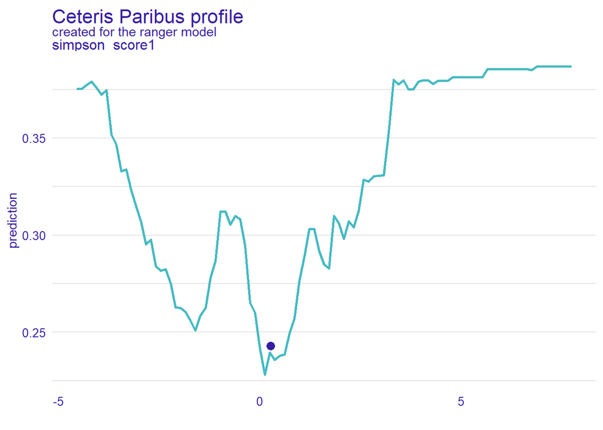

```r
plot(cp_ranger_test, variables = c("simpson_score1", "simpson_score1"))
```

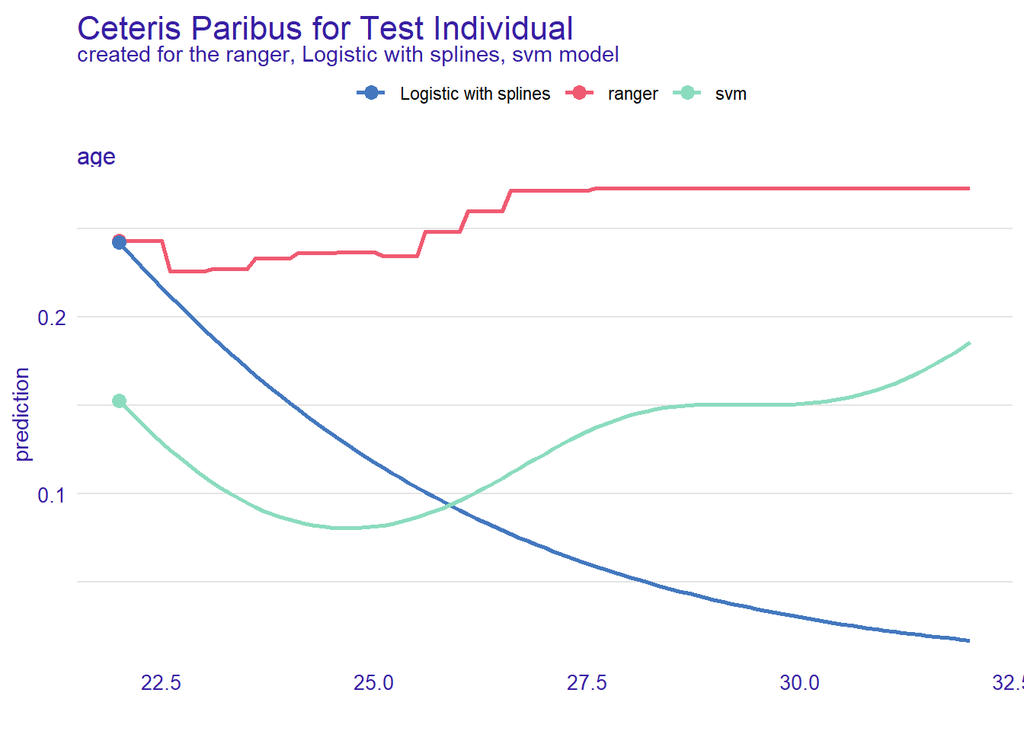

```r
#
# 14. Profiles for the models
# logistic with splines
cp_rms_test <- predict_profile(exp_rms_test, Test_person)
# support vector machine
cp_svm_test <- predict_profile(exp_svm_test, Test_person)

plot(cp_ranger_test, cp_rms_test,cp_svm_test, variables = "age", color = "_label_") +
  ggtitle("Ceteris Paribus for Test Individual")
```

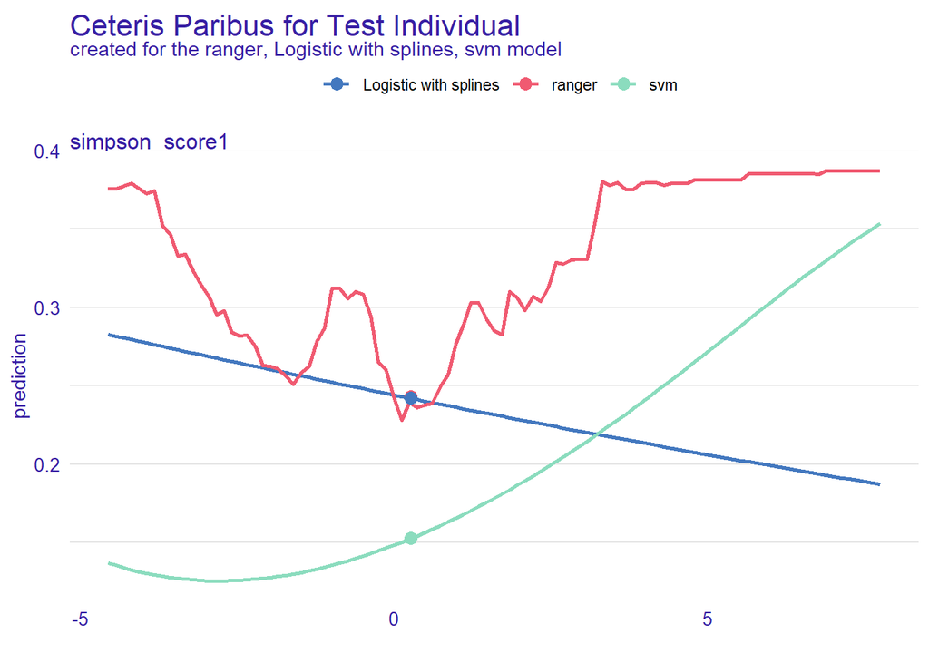

```r
plot(cp_ranger_test, cp_rms_test,cp_svm_test, variables = "simpson_score1", color = "_label_") +
  ggtitle("Ceteris Paribus for Test Individual")
```

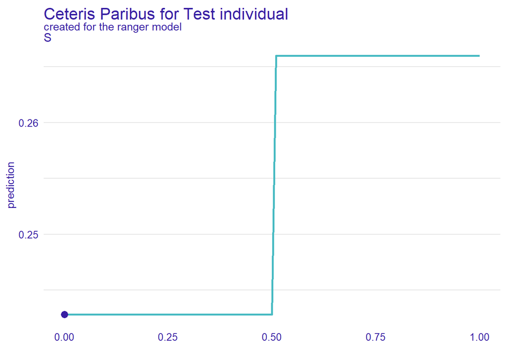

```r
#
# 15. How important are variables

cp_rms_test <- predict_parts(exp_rms_test, Test_person, type = "oscillations")

#
# 16. For categorical variables

plot(cp_ranger_test, variables = "S", categorical_type = "bars") +
  ggtitle("Ceteris Paribus for Test individual")
```

## Fairness

We have seen the model explanation with Dalex and the analysis of the ROC curves, now we’ll deal with the fairness check. we need a model and an explainer created from DALEX.

from “Fairmodels advanced Tutorial” https://modeloriented.github.io/fairmodels/articles/Advanced_tutorial.html

```r
# recap of the 3 explainers
exp_ranger_test
```

```
## Model label:  ranger
## Model class:  ranger
## Data head  :
##   S interview Github_account     proxy     proxy2 age X_score score
## 3 0         9              0 1.2772139 0.05820192  23     105     6
## 4 0         5              0 0.5206696 0.28859022  22      96     6
##   simpson_score1 simpson_score2 trtGrp
## 3      0.6979309       3.640835      2
## 4      1.0350677      -2.145873      1
```

```r
exp_rms_test
```

```
## Model label:  Logistic with splines
## Model class:  lrm,rms,glm
## Data head  :
##   S interview Github_account     proxy     proxy2 age X_score score
## 3 0         9              0 1.2772139 0.05820192  23     105     6
## 4 0         5              0 0.5206696 0.28859022  22      96     6
##   simpson_score1 simpson_score2 trtGrp
## 3      0.6979309       3.640835      2
## 4      1.0350677      -2.145873      1
```

```r
exp_svm_test
```

```
## Model label:  svm
## Model class:  svm.formula,svm
## Data head  :
##   S interview Github_account     proxy     proxy2 age X_score score
## 3 0         9              0 1.2772139 0.05820192  23     105     6
## 4 0         5              0 0.5206696 0.28859022  22      96     6
##   simpson_score1 simpson_score2 trtGrp
## 3      0.6979309       3.640835      2
## 4      1.0350677      -2.145873      1
```

```r
library(fairmodels)

fobject_rf <- fairness_check(exp_ranger_test,
                          protected  = data_test$S, # sensitive feature
                          privileged = "0", # males
                          colorize = FALSE)
```

```
## Creating fairness classification object
## -> Privileged subgroup       : character ( Ok  )
## -> Protected variable        : factor ( changed from numeric  )
## -> Cutoff values for explainers  : 0.5 ( for all subgroups )
## -> Fairness objects      : 0 objects
## -> Checking explainers       : 1 in total (  compatible  )
## -> Metric calculation        : 13/13 metrics calculated for all models
##  Fairness object created succesfully
```

```r
print(fobject_rf, colorize = FALSE)
```

```
##
## Fairness check for models: ranger
##
## ranger passes 2/5 metrics
## Total loss :  2.745686
```

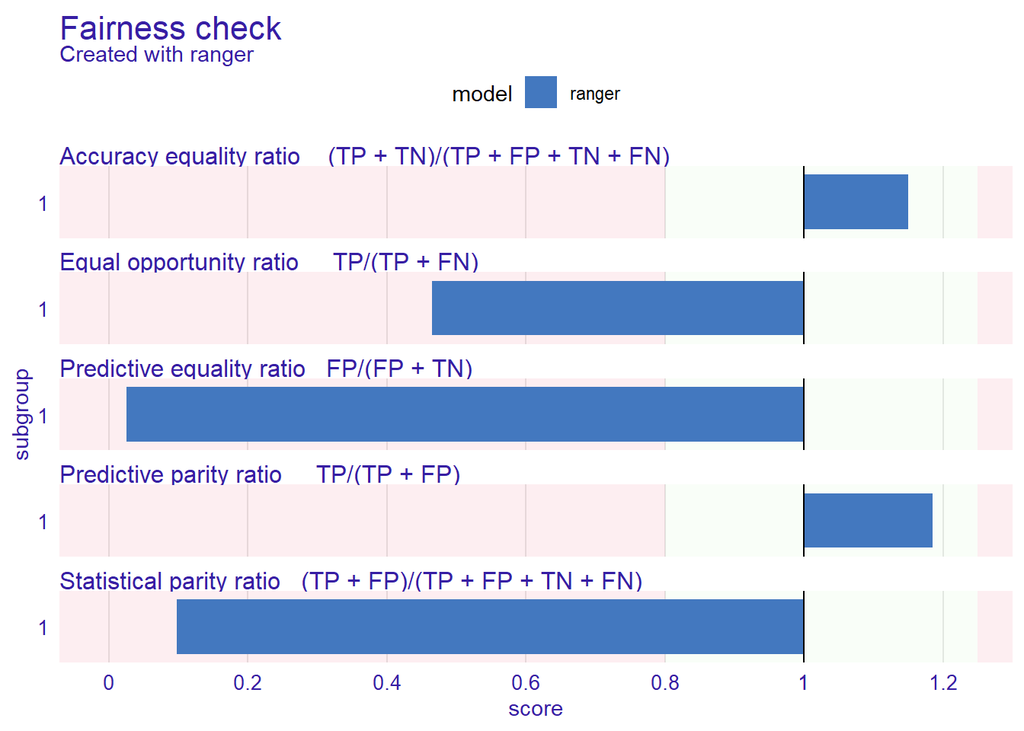

```r
# how big is the BIAS?
gg_fair_rf <- plot(fobject_rf)
gg_fair_rf
```

```r
# logistic regression

fobject_rms <- fairness_check(exp_rms_test,
                          protected  = data_test$S, # sensitive feature
                          privileged = "0",
                          colorize = FALSE)
```

```
## Creating fairness classification object
## -> Privileged subgroup       : character ( Ok  )
## -> Protected variable        : factor ( changed from numeric  )
## -> Cutoff values for explainers  : 0.5 ( for all subgroups )
## -> Fairness objects      : 0 objects
## -> Checking explainers       : 1 in total (  compatible  )
## -> Metric calculation        : 13/13 metrics calculated for all models
##  Fairness object created succesfully
```

```r
print(fobject_rms, colorize = FALSE)
```

```
##
## Fairness check for models: Logistic with splines
##
## Logistic with splines passes 2/5 metrics
## Total loss :  2.563634
```

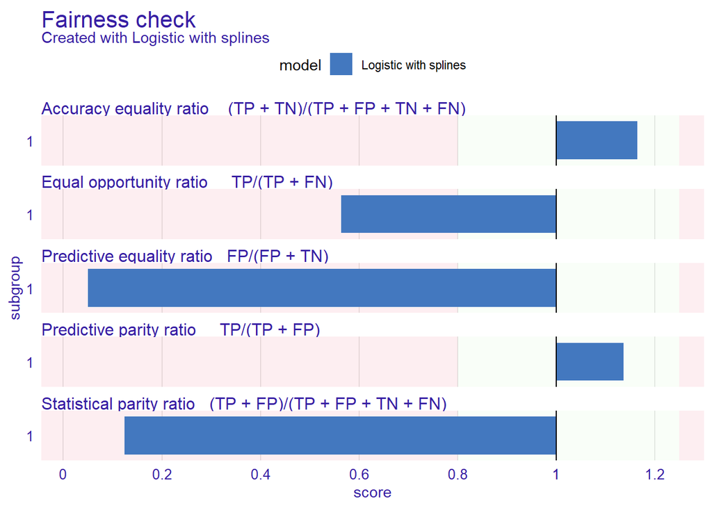

```r
# how big is the BIAS?
gg_fair_rms <- plot(fobject_rms)
gg_fair_rms
```

```r
# svm

fobject_svm <- fairness_check(exp_svm_test,
                          protected  = data_test$S, # sensitive feature
                          privileged = "0",
                          colorize = FALSE)
```

```
## Creating fairness classification object
## -> Privileged subgroup       : character ( Ok  )
## -> Protected variable        : factor ( changed from numeric  )
## -> Cutoff values for explainers  : 0.5 ( for all subgroups )
## -> Fairness objects      : 0 objects
## -> Checking explainers       : 1 in total (  compatible  )
## -> Metric calculation        : 13/13 metrics calculated for all models
##  Fairness object created succesfully
```

```r
print(fobject_svm, colorize = FALSE)
```

```
##
## Fairness check for models: svm
##
## svm passes 2/5 metrics
## Total loss :  2.593088
```

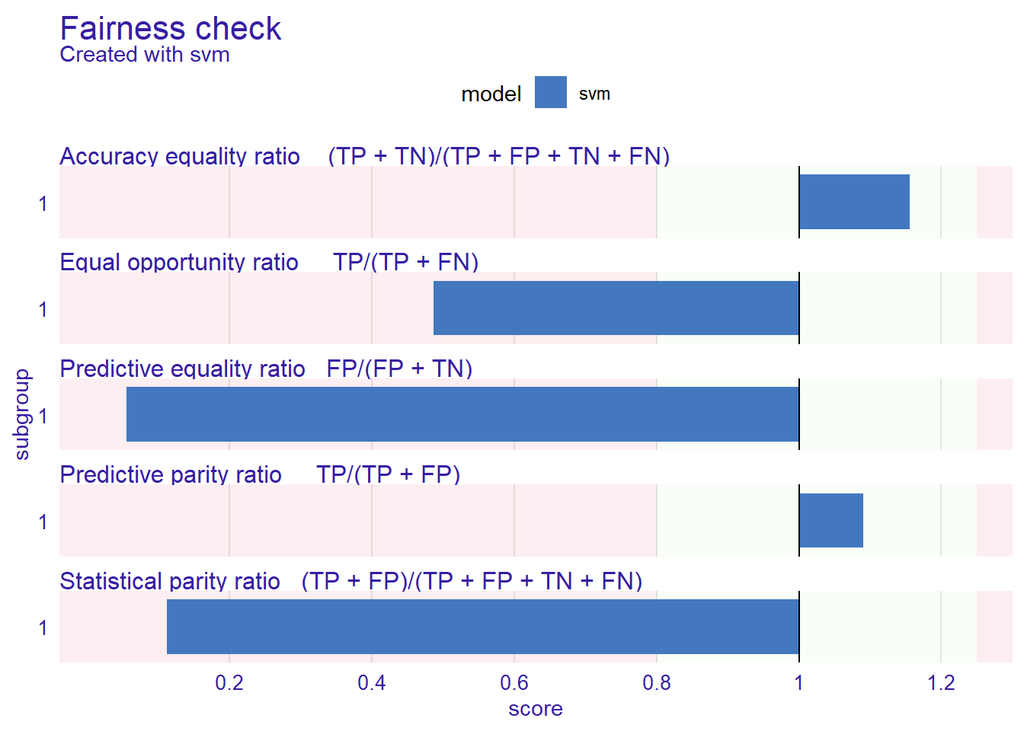

```r
# how big is the BIAS?
gg_fair_svm <- plot(fobject_svm)
gg_fair_svm
```

Continue to adapt the code in “Fairness sim_data”

## Bias mitigation strategies

# Pre processing techniques

these techniques are applied before the model training aiming to reduce the BIAS in the DATA, i’ll start with the default functions and later i will try to apply custom weights and the counterfactuals. Through parameter lambda we can manipulate with how much the distribution will be fixed. lambda = 1 (default) will return data with identical distributions for all levels of protected variable whereas lambda = 0 will barely change anything. We will transform a few features including the simpsons scores in order to mitigate the discriminatory effect of those variables in the prediction. (see fairmodels)

## Reweighting the data

from page 74 RESPONSIBLE AI

```r
## 1
# define the favourable and unfavourable outcome
library(gbm)
setwd("C:/Users/Davide Zulato/Desktop/Sim_Data")
data_bias <- df

n <- nrow(data_bias)

sa <- nrow(data_bias[which(data_bias$S==0),]) # total number of privileged
sd <- nrow(data_bias[which(data_bias$S==1),]) # total number of unprivileged
ypos <- nrow(data_bias[which(data_bias$Y==1),]) # total number of favourable
yneg <- nrow(data_bias[which(data_bias$Y==0),]) # total number of unfavourable
sa;sd;ypos;yneg
```

```
## [1] 7928
```

```
## [1] 2072
```

```
## [1] 2910
```

```
## [1] 7090
```

```r
data_sa_ypos <- data_bias[which(data_bias$S==0 & data_bias$Y==1),] # privileged and favourable
data_sa_yneg <- data_bias[which(data_bias$S==0 & data_bias$Y==0),] # privileged and unfavourable
data_sd_ypos <- data_bias[which(data_bias$S==1 & data_bias$Y==1),] # unprivileged and favourable
data_sd_yneg <- data_bias[which(data_bias$S==1 & data_bias$Y==0),] # unprivileged and unfavourable

sa_ypos <- nrow(data_sa_ypos) # total number of privileged and favourable
sa_yneg <- nrow(data_sa_yneg) # total number of privileged and unfavourable
sd_ypos <- nrow(data_sd_ypos) # total number of unprivileged and favourable
sd_yneg <- nrow(data_sd_yneg) # total number of unprivileged and unfavourable
paste0("Total number of advantaged and favourable:",sa_ypos)
```

```
## [1] "Total number of advantaged and favourable:2730"
```

```r
paste0("Total number of advantaged and unfavourable:",sa_yneg)
```

```
## [1] "Total number of advantaged and unfavourable:5198"
```

```r
paste0("Total number of disadvantaged and favourable:",sd_ypos)
```

```
## [1] "Total number of disadvantaged and favourable:180"
```

```r
paste0("Total number of disadvantaged and unfavourable:",sd_yneg)
```

```
## [1] "Total number of disadvantaged and unfavourable:1892"
```

```r
w_sa_ypos <- (ypos*sa)/(n*sa_ypos) # weight for privileged and favourable
w_sa_yneg <- (yneg*sa)/(n*sa_yneg) # weight for privileged and unfavourable
w_sd_ypos <- (ypos*sd)/(n*sd_ypos) # weight for unprivileged and favourable
w_sd_yneg <- (yneg*sd)/(n*sd_yneg) # weight for unprivileged and unfavaurable

datatest <- data_bias

discrimination_before <- (sa_ypos/sa)-(sd_ypos/sd)
round(discrimination_before,3)
```

```
## [1] 0.257
```

```r
discrimination_after <- (sa_ypos/sa * w_sa_ypos)-(sd_ypos/sd * w_sd_ypos)
round(discrimination_after,3)
```

```
## [1] 0
```

```r
# assign weights
datatest$weights <- vector(mode="numeric",length = nrow(datatest))
datatest$weights[which(datatest$S==0 & datatest$Y==1)] = w_sa_ypos
datatest$weights[which(datatest$S==0 & datatest$Y==0)] = w_sa_yneg
datatest$weights[which(datatest$S==1 & datatest$Y==1)] = w_sd_ypos
datatest$weights[which(datatest$S==1 & datatest$Y==0)] = w_sd_yneg

# afrer the fairness_sim_data GBM you could run the following code
weights_custom <- datatest$weights

set.seed(876101)
gbm_model    <- gbm(Y ~. ,
                     data = df,
                     distribution = "bernoulli")
weights <- fairmodels::reweight(protected = df$S,y=df$Y)
```

```
##
## changing protected to factor
```

```r
gbm_model1    <- gbm(Y ~. ,
                     data = df,
                     weights= weights,
                     distribution = "bernoulli")
gbm_model2     <- gbm(Y ~. ,
                     data = df,
                     weights = weights_custom, # weights custom
                     distribution = "bernoulli")
gbm_explainer <- DALEX::explain(gbm_model,
                                  data = df[,-13],
                                  y = df$Y,
                                  label = "gbm",
                                  verbose = FALSE)
gbm_explainer_w <- DALEX::explain(gbm_model1,
                                  data = df[,-13],
                                  y = df$Y,
                                  label = "gbm_custom_weight",
                                  verbose = FALSE)
gbm_explainer_cw <- DALEX::explain(gbm_model2,
                                  data = df[,-13],
                                  y = df$Y,
                                  label = "gbm_custom_weight",
                                  verbose = FALSE)

fobject_custom <- fairness_check(gbm_explainer_cw,gbm_explainer,protected = factor(datatest$S),privileged = "0")
```

```
## Creating fairness classification object
## -> Privileged subgroup       : character ( Ok  )
## -> Protected variable        : factor ( Ok  )
## -> Cutoff values for explainers  : 0.5 ( for all subgroups )
## -> Fairness objects      : 0 objects
## -> Checking explainers       : 2 in total (  compatible  )
## -> Metric calculation        : 13/13 metrics calculated for all models
##  Fairness object created succesfully
```

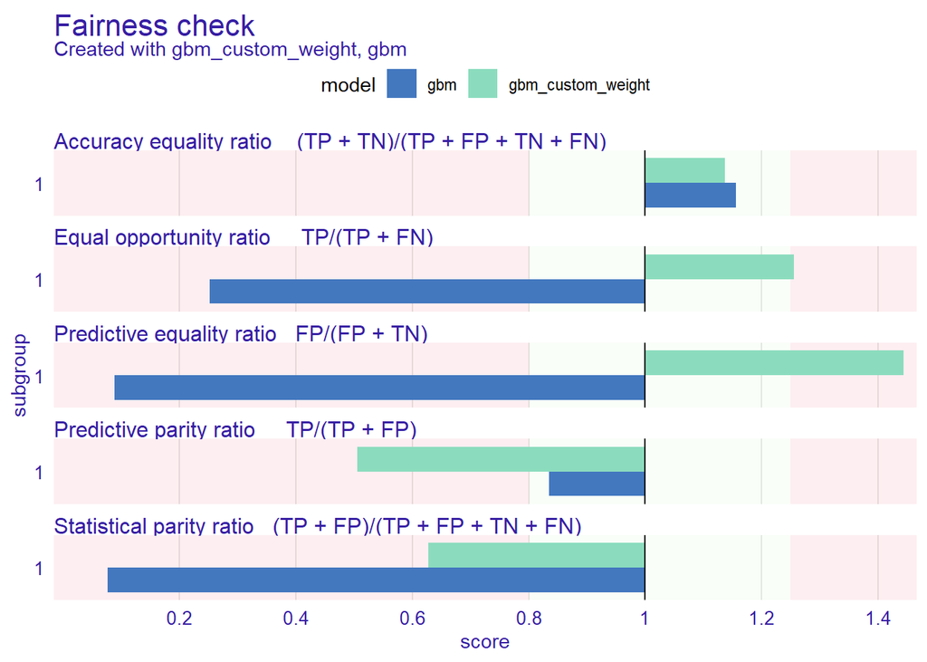

```r
plot(fobject_custom)
```

```r
 #fobject <- fairness_check(fobject_custom,gbm_explainer_w,protected = factor(datatest$S),privileged = "0")
#plot(fobject_custom)
# plot(fobject)
# they look very similar to the weights in the function "reweight" in package fairmodels
```